# Exploratory Data Analysis - Home Credit Default Risk

Tom Kingston

2023-10-06

### Introduction

In the context of the Home Credit Default Risk project, we are confronted with a significant business challenge: the need to assess and mitigate the risk of loan default among our clients. The problem is two-fold: a considerable portion of our loan applicants fall into the high-risk category, resulting in substantial financial losses for our organization. This not only impacts our profitability but also hinders our mission to provide accessible financial services to a broader range of individuals. To address this, we seek a solution that will enable us to identify creditworthy applicants more accurately, reduce default rates, and ultimately enhance our financial stability.

### Description of data

We was provided with a few data sets from the Home Credit Default Risk Team. The dataset comprises a collection of CSV files, each with a unique purpose in the realm of Home Credit loan default prediction. The central dataset, “application_{train|test}.csv,” is divided into training and test sets and serves as the bedrock for static data on loan applications. Each row in this dataset represents an individual loan application, with the “TARGET” variable indicating loan default status, exclusively present in the training set. Supplementing this primary dataset are several others, including “bureau.csv” and “bureau_balance.csv,” which offer insights into clients’ past credit histories reported to Credit Bureau, down to monthly balance snapshots of previous credits. “POS_CASH_balance.csv” and “credit_card_balance.csv” delve into the monthly balance records of point-of-sale, cash, and credit card loans, respectively, providing a granular view of client credit usage. “previous_application.csv” compiles records of all prior Home Credit loan applications from clients in the sample, while “installments_payments.csv” captures repayment histories, encompassing successful payments and missed ones. Finally, “HomeCredit_columns_description.csv” serves as a reference guide, offering descriptions for the columns present in the various data files, facilitating a deeper understanding of the dataset’s variables. Together, these datasets form a comprehensive resource for developing predictive models to assess loan default risk in the context of Home Credit.

### Load data

```r
# Load necessary libraries
library(tidyverse)
library(naniar)  # Use naniar for handling missing data

# Load the training data
train_data <- read.csv("application_train.csv")

# Load the test data
test_data <- read.csv("application_test.csv")

# Load transactional data (e.g., bureau.csv)
bureau_data <- read.csv("bureau.csv")
```

### View Summary of data

```r
summary(train_data)
```

```
##    SK_ID_CURR         TARGET        NAME_CONTRACT_TYPE CODE_GENDER
##  Min.   :100002   Min.   :0.00000   Length:307511      Length:307511
##  1st Qu.:189146   1st Qu.:0.00000   Class :character   Class :character
##  Median :278202   Median :0.00000   Mode  :character   Mode  :character
##  Mean   :278180   Mean   :0.08073
##  3rd Qu.:367142   3rd Qu.:0.00000
##  Max.   :456255   Max.   :1.00000
##
##  FLAG_OWN_CAR       FLAG_OWN_REALTY     CNT_CHILDREN     AMT_INCOME_TOTAL
##  Length:307511      Length:307511      Min.   : 0.0000   Min.   :    25650
##  Class :character   Class :character   1st Qu.: 0.0000   1st Qu.:   112500
##  Mode  :character   Mode  :character   Median : 0.0000   Median :   147150
##                                        Mean   : 0.4171   Mean   :   168798
##                                        3rd Qu.: 1.0000   3rd Qu.:   202500
##                                        Max.   :19.0000   Max.   :117000000
##
##    AMT_CREDIT       AMT_ANNUITY     AMT_GOODS_PRICE   NAME_TYPE_SUITE
##  Min.   :  45000   Min.   :  1616   Min.   :  40500   Length:307511
##  1st Qu.: 270000   1st Qu.: 16524   1st Qu.: 238500   Class :character
##  Median : 513531   Median : 24903   Median : 450000   Mode  :character
##  Mean   : 599026   Mean   : 27109   Mean   : 538396
##  3rd Qu.: 808650   3rd Qu.: 34596   3rd Qu.: 679500
##  Max.   :4050000   Max.   :258026   Max.   :4050000
##                    NA's   :12       NA's   :278
##  NAME_INCOME_TYPE   NAME_EDUCATION_TYPE NAME_FAMILY_STATUS NAME_HOUSING_TYPE
##  Length:307511      Length:307511       Length:307511      Length:307511
##  Class :character   Class :character    Class :character   Class :character
##  Mode  :character   Mode  :character    Mode  :character   Mode  :character
##
##
##
##
##  REGION_POPULATION_RELATIVE   DAYS_BIRTH     DAYS_EMPLOYED    DAYS_REGISTRATION
##  Min.   :0.00029            Min.   :-25229   Min.   :-17912   Min.   :-24672
##  1st Qu.:0.01001            1st Qu.:-19682   1st Qu.: -2760   1st Qu.: -7480
##  Median :0.01885            Median :-15750   Median : -1213   Median : -4504
##  Mean   :0.02087            Mean   :-16037   Mean   : 63815   Mean   : -4986
##  3rd Qu.:0.02866            3rd Qu.:-12413   3rd Qu.:  -289   3rd Qu.: -2010
##  Max.   :0.07251            Max.   : -7489   Max.   :365243   Max.   :     0
##
```

[output cut: 225 more lines]

```
##  Min.   :0.00               Min.   : 0.00             Min.   :  0.00
##  1st Qu.:0.00               1st Qu.: 0.00             1st Qu.:  0.00
##  Median :0.00               Median : 0.00             Median :  0.00
##  Mean   :0.03               Mean   : 0.27             Mean   :  0.27
##  3rd Qu.:0.00               3rd Qu.: 0.00             3rd Qu.:  0.00
##  Max.   :8.00               Max.   :27.00             Max.   :261.00
##  NA's   :41519              NA's   :41519             NA's   :41519
##  AMT_REQ_CREDIT_BUREAU_YEAR
##  Min.   : 0.0
##  1st Qu.: 0.0
##  Median : 1.0
##  Mean   : 1.9
##  3rd Qu.: 3.0
##  Max.   :25.0
##  NA's   :41519
```

```r
summary(test_data)
```

```
##    SK_ID_CURR     NAME_CONTRACT_TYPE CODE_GENDER        FLAG_OWN_CAR
##  Min.   :100001   Length:48744       Length:48744       Length:48744
##  1st Qu.:188558   Class :character   Class :character   Class :character
##  Median :277549   Mode  :character   Mode  :character   Mode  :character
##  Mean   :277797
##  3rd Qu.:367556
##  Max.   :456250
##
##  FLAG_OWN_REALTY     CNT_CHILDREN     AMT_INCOME_TOTAL    AMT_CREDIT
##  Length:48744       Min.   : 0.0000   Min.   :  26942   Min.   :  45000
##  Class :character   1st Qu.: 0.0000   1st Qu.: 112500   1st Qu.: 260640
##  Mode  :character   Median : 0.0000   Median : 157500   Median : 450000
##                     Mean   : 0.3971   Mean   : 178432   Mean   : 516740
##                     3rd Qu.: 1.0000   3rd Qu.: 225000   3rd Qu.: 675000
##                     Max.   :20.0000   Max.   :4410000   Max.   :2245500
##
##   AMT_ANNUITY     AMT_GOODS_PRICE   NAME_TYPE_SUITE    NAME_INCOME_TYPE
##  Min.   :  2295   Min.   :  45000   Length:48744       Length:48744
##  1st Qu.: 17973   1st Qu.: 225000   Class :character   Class :character
##  Median : 26199   Median : 396000   Mode  :character   Mode  :character
##  Mean   : 29426   Mean   : 462619
##  3rd Qu.: 37390   3rd Qu.: 630000
##  Max.   :180576   Max.   :2245500
##  NA's   :24
##  NAME_EDUCATION_TYPE NAME_FAMILY_STATUS NAME_HOUSING_TYPE
##  Length:48744        Length:48744       Length:48744
##  Class :character    Class :character   Class :character
##  Mode  :character    Mode  :character   Mode  :character
##
##
##
##
##  REGION_POPULATION_RELATIVE   DAYS_BIRTH     DAYS_EMPLOYED    DAYS_REGISTRATION
##  Min.   :0.000253           Min.   :-25195   Min.   :-17463   Min.   :-23722
##  1st Qu.:0.010006           1st Qu.:-19637   1st Qu.: -2910   1st Qu.: -7459
##  Median :0.018850           Median :-15785   Median : -1293   Median : -4490
##  Mean   :0.021226           Mean   :-16068   Mean   : 67485   Mean   : -4968
##  3rd Qu.:0.028663           3rd Qu.:-12496   3rd Qu.:  -296   3rd Qu.: -1901
##  Max.   :0.072508           Max.   : -7338   Max.   :365243   Max.   :     0
##
```

[output cut: 217 more lines]

```
##  Min.   :0.000              Min.   :0.000             Min.   :0.000
##  1st Qu.:0.000              1st Qu.:0.000             1st Qu.:0.000
##  Median :0.000              Median :0.000             Median :0.000
##  Mean   :0.003              Mean   :0.009             Mean   :0.547
##  3rd Qu.:0.000              3rd Qu.:0.000             3rd Qu.:1.000
##  Max.   :2.000              Max.   :6.000             Max.   :7.000
##  NA's   :6049               NA's   :6049              NA's   :6049
##  AMT_REQ_CREDIT_BUREAU_YEAR
##  Min.   : 0.000
##  1st Qu.: 0.000
##  Median : 2.000
##  Mean   : 1.984
##  3rd Qu.: 3.000
##  Max.   :17.000
##  NA's   :6049
```

```r
summary(bureau_data)
```

```
##    SK_ID_CURR      SK_ID_BUREAU     CREDIT_ACTIVE      CREDIT_CURRENCY
##  Min.   :100001   Min.   :5000000   Length:1716428     Length:1716428
##  1st Qu.:188867   1st Qu.:5463954   Class :character   Class :character
##  Median :278055   Median :5926304   Mode  :character   Mode  :character
##  Mean   :278215   Mean   :5924434
##  3rd Qu.:367426   3rd Qu.:6385681
##  Max.   :456255   Max.   :6843457
##
##   DAYS_CREDIT    CREDIT_DAY_OVERDUE  DAYS_CREDIT_ENDDATE DAYS_ENDDATE_FACT
##  Min.   :-2922   Min.   :   0.0000   Min.   :-42060.0    Min.   :-42023
##  1st Qu.:-1666   1st Qu.:   0.0000   1st Qu.: -1138.0    1st Qu.: -1489
##  Median : -987   Median :   0.0000   Median :  -330.0    Median :  -897
##  Mean   :-1142   Mean   :   0.8182   Mean   :   510.5    Mean   : -1017
##  3rd Qu.: -474   3rd Qu.:   0.0000   3rd Qu.:   474.0    3rd Qu.:  -425
##  Max.   :    0   Max.   :2792.0000   Max.   : 31199.0    Max.   :     0
##                                      NA's   :105553      NA's   :633653
##  AMT_CREDIT_MAX_OVERDUE CNT_CREDIT_PROLONG AMT_CREDIT_SUM
##  Min.   :        0      Min.   :0.00000    Min.   :        0
##  1st Qu.:        0      1st Qu.:0.00000    1st Qu.:    51300
##  Median :        0      Median :0.00000    Median :   125518
##  Mean   :     3825      Mean   :0.00641    Mean   :   354995
##  3rd Qu.:        0      3rd Qu.:0.00000    3rd Qu.:   315000
##  Max.   :115987185      Max.   :9.00000    Max.   :585000000
##  NA's   :1124488                           NA's   :13
##  AMT_CREDIT_SUM_DEBT AMT_CREDIT_SUM_LIMIT AMT_CREDIT_SUM_OVERDUE
##  Min.   : -4705600   Min.   :-586406      Min.   :      0
##  1st Qu.:        0   1st Qu.:      0      1st Qu.:      0
##  Median :        0   Median :      0      Median :      0
##  Mean   :   137085   Mean   :   6230      Mean   :     38
##  3rd Qu.:    40154   3rd Qu.:      0      3rd Qu.:      0
##  Max.   :170100000   Max.   :4705600      Max.   :3756681
##  NA's   :257669      NA's   :591780
##  CREDIT_TYPE        DAYS_CREDIT_UPDATE  AMT_ANNUITY
##  Length:1716428     Min.   :-41947.0   Min.   :        0
##  Class :character   1st Qu.:  -908.0   1st Qu.:        0
##  Mode  :character   Median :  -395.0   Median :        0
##                     Mean   :  -593.8   Mean   :    15713
##                     3rd Qu.:   -33.0   3rd Qu.:    13500
##                     Max.   :   372.0   Max.   :118453424
##                                        NA's   :1226791
```

### Task 1 Explore the target variable analysis:

```r
# Task 1: Explore the Target Variable
target_counts <- table(train_data$TARGET)
print("Distribution of TARGET variable:")
```

```
## [1] "Distribution of TARGET variable:"
```

```r
print(target_counts)
```

```
##
##      0      1
## 282686  24825
```

We examined the distribution of the target variable, a pivotal step in assessing the balance of classes for a binary classification problem. The results unveiled two distinct classes within the target variable: - Class 0: Comprising a substantial 282,686 instances, this class represents clients who did not encounter payment difficulties, signifying no default. - Class 1: In contrast, this class includes 24,825 instances, representing clients who did experience payment difficulties, indicating default. These findings highlight a pronounced class imbalance within the dataset, with a significantly larger number of clients categorized as non-default (Class 0) compared to those in the default category (Class 1). To build accurate predictive models, addressing this imbalance may necessitate employing specialized techniques like oversampling or undersampling to mitigate its potential impact on model performance.

### Task 2 Explore the relationship between target and predictors analysis:

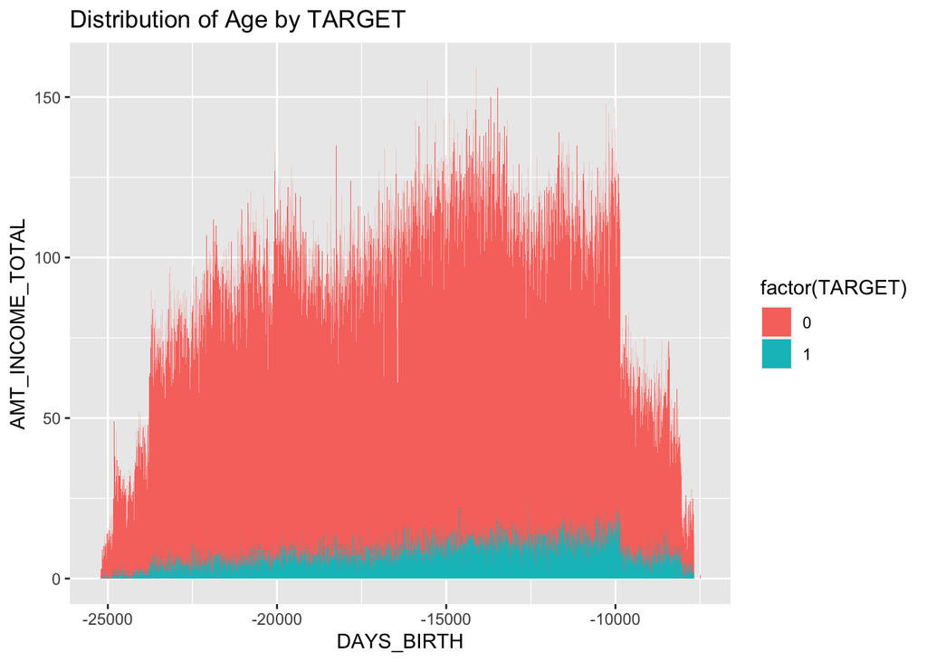

```r
# Task 2: Explore the Relationship Between "TARGET" and Predictors
# Example: Histogram of Age vs. "TARGET"
ggplot(train_data, aes(x=DAYS_BIRTH, fill=factor(TARGET))) +
  geom_histogram(binwidth=5) +
  labs(title="Distribution of Age by TARGET") +
  xlab("DAYS_BIRTH") +
  ylab("AMT_INCOME_TOTAL")
```

### Task 3 Explore Missing Data and Data Cleaning analysis:

```r
# Task 3: Explore Missing Data and Data Cleaning
# Check for missing data in training and test datasets
missing_train <- sum(is.na(train_data))
missing_test <- sum(is.na(test_data))
print("Missing data in training dataset:")
```

```
## [1] "Missing data in training dataset:"
```

```r
print(missing_train)
```

```
## [1] 8388094
```

```r
print("Missing data in test dataset:")
```

```
## [1] "Missing data in test dataset:"
```

```r
print(missing_test)
```

```
## [1] 1285385
```

These results indicate the extent of missing data in both the training and test datasets: - In the training dataset, there are 8,388,094 missing values across all columns. This suggests that a substantial portion of the data is incomplete, potentially requiring data imputation or careful handling during analysis. - In the test dataset, there are 1,285,385 missing values. While this dataset typically represents unseen data for predictive modeling, it’s important to note the extent of missing values, as it may affect the application of models trained on the training dataset to new, unseen data. These results highlight the need for addressing missing data, whether through imputation techniques, data cleaning, or considering how to handle these missing values during modeling. Failure to handle missing data appropriately can lead to biased or inaccurate results in predictive models.

### Task 4 data quality check analysis

```r
# Task 4: Data Quality Check
# Example: Check if any income values are negative
negative_income_count <- sum(train_data$AMT_INCOME_TOTAL < 0)
cat("Number of negative income values:", negative_income_count, "\n")
```

```
## Number of negative income values: 0
```

This finding suggests that there are no instances of negative income values within the dataset, aligning with our expectations regarding income data. It’s essential to recognize that, in a financial dataset like this, negative income values would be unusual and could signal data quality issues or errors.

The absence of negative income values provides confidence that the data is consistent with the financial domain’s standards, where income is generally expected to be non-negative. As a college student, understanding and validating the quality of data is crucial, and this result indicates that the dataset appears to be reliable in this specific aspect. However, it’s still essential to conduct a comprehensive data quality assessment to address potential issues in other areas of the dataset.

### Task 5 Data transformation

```r
# Task 5: Data Transformation
# Example: Encoding categorical variables
train_data$CODE_GENDER <- as.factor(train_data$CODE_GENDER)
```

### Task 6 Join transactional data

```r
# Task 6: Join with Transactional Data
# Join transactional data (e.g., bureau.csv) with application data
joined_data <- inner_join(train_data, bureau_data, by="SK_ID_CURR")
```

### Task 7 Explore johned transactional data analysis:

```r
# Task 7: Explore Joined Transactional Data
# Example: Correlation heatmap
correlation_matrix <- cor(joined_data[, c("TARGET", "AMT_INCOME_TOTAL")], use="complete.obs")
print("Correlation Matrix:")
```

```
## [1] "Correlation Matrix:"
```

```r
print(correlation_matrix)
```

```
##                         TARGET AMT_INCOME_TOTAL
## TARGET            1.0000000000    -0.0002787734
## AMT_INCOME_TOTAL -0.0002787734     1.0000000000
```

This reveals the correlations between the “TARGET” variable (representing loan default) and the “AMT_INCOME_TOTAL” variable (representing the total income of clients). In this specific case, The correlation between “TARGET” and “AMT_INCOME_TOTAL” is approximately -0.00028. This value is very close to zero, indicating an extremely weak and almost negligible correlation between the target variable (loan default) and the total income of clients. In other words, there is almost no linear relationship between these two variables. These results suggest that the total income of clients, as represented by “AMT_INCOME_TOTAL,” is not a strong linear predictor of loan default in this dataset. While correlation does not capture all potential relationships between variables, this finding implies that other factors or variables may play a more significant role in predicting loan default, and further exploration or modeling is needed to identify such predictors.